# 1 Background

As a statistical consultant working for a real estate investment firm, your task is to develop a model to predict the selling price of a given home in Ames, Iowa. Your employer hopes to use this information to help assess whether the asking price of a house is higher or lower than the true value of the house. If the home is undervalued, it may be a good investment for the firm.

# 2 Training Data and relevant packages

In order to better assess the quality of the model you will produce, the data have been randomly divided into three separate pieces: a training data set, a testing data set, and a validation data set. For now we will load the training data set, the others will be loaded and used later.

```r
load("ames_train.Rdata")
options(expressions= 100000)
```

Use the code block below to load any necessary packages

```r
library(statsr)
library(dplyr)
library(BAS)
```

```r
library(ggplot2)
library(scales)
library(kableExtra)
library(formattable)
library(devtools)
library(MASS)
library(GGally)
```

## 2.1 Part 1 - Exploratory Data Analysis (EDA)

When you first get your data, it’s very tempting to immediately begin fitting models and assessing how they perform. However, before you begin modeling, it’s absolutely essential to explore the structure of the data and the relationships between the variables in the data set.

Do a detailed EDA of the ames_train data set, to learn about the structure of the data and the relationships between the variables in the data set (refer to Introduction to Probability and Data, Week 2, for a reminder about EDA if needed). Your EDA should involve creating and reviewing many plots/graphs and considering the patterns and relationships you see.

After you have explored completely, submit the three graphs/plots that you found most informative during your EDA process, and briefly explain what you learned from each (why you found each informative).

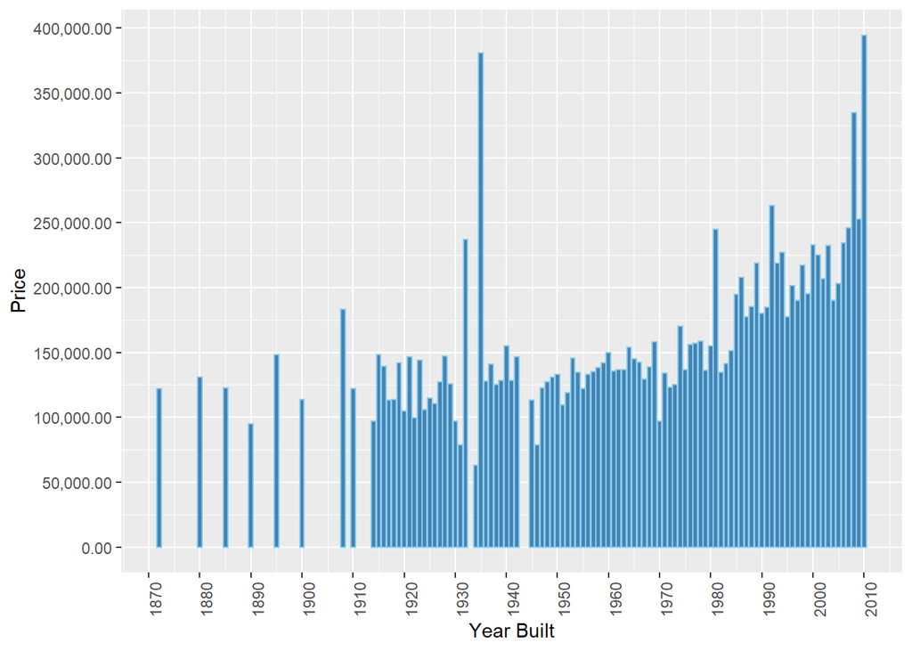

```r
data1 <- ames_train %>%
  mutate(SqFt = X1st.Flr.SF + X2nd.Flr.SF) %>%
  mutate(baths = Full.Bath + 0.5*Half.Bath) %>%
  dplyr::select(price, Overall.Qual, Garage.Area, Total.Bsmt.SF, Garage.Cars, area, baths,
                Bedroom.AbvGr, Year.Built, SqFt, Lot.Area, Central.Air, Overall.Cond)

data2 <- data1 %>%
  group_by(Year.Built) %>%
  summarise(medianPrice = median(price), meanPrice = mean(price))

ggplot(data=data2, aes(x = Year.Built, y = medianPrice)) +
  geom_bar(stat="identity", color='skyblue', fill='steelblue') +
  theme(axis.text.x = element_text(angle = 90)) +
  scale_x_continuous(breaks=seq(1870,2010,10), name = 'Year Built') +
  scale_y_continuous(breaks=seq(0,400000,50000), name = 'Price', labels = comma)
```

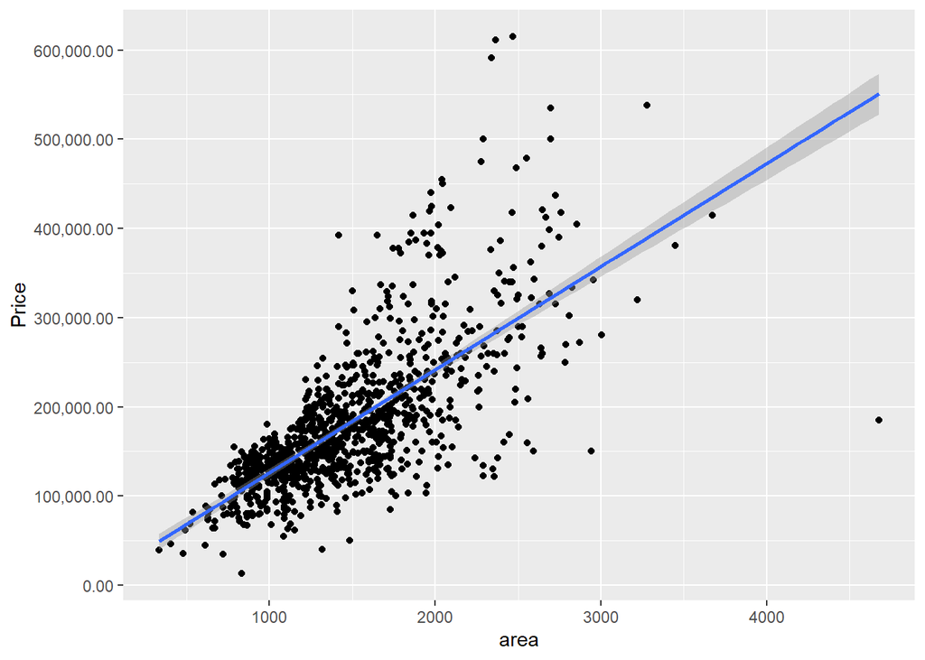

```r
ggplot(data1, aes(x=area, y=price)) +
  geom_point()+
  geom_smooth(method=lm) +
  scale_y_continuous(breaks=seq(0,700000,100000), name = 'Price', labels = comma)
```

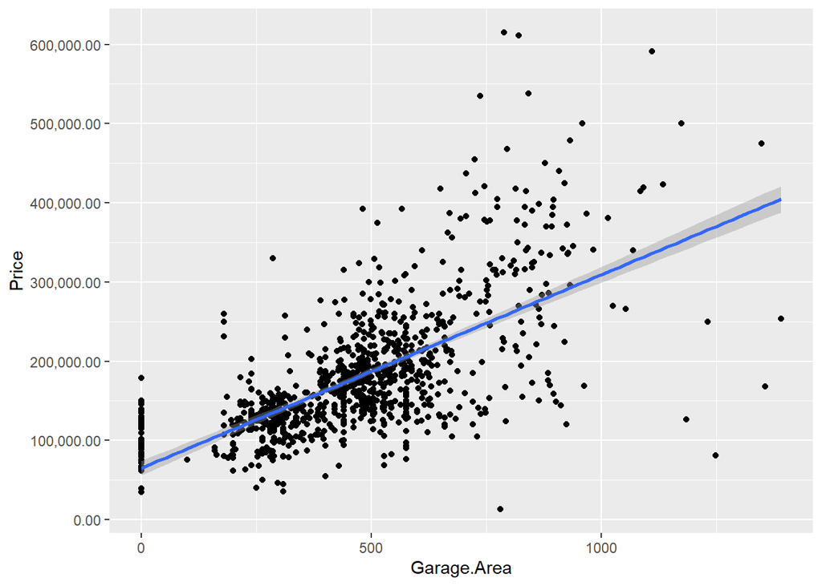

```r
ggplot(data1, aes(x=Garage.Area, y=price)) +
  geom_point()+
  geom_smooth(method=lm) +
  scale_y_continuous(breaks=seq(0,700000,100000), name = 'Price', labels = comma)
```

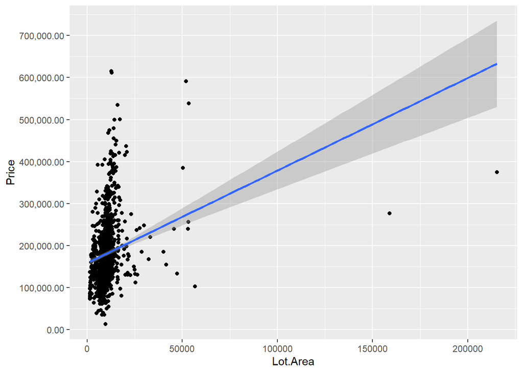

```r
ggplot(data1, aes(x=Lot.Area, y=price)) +
  geom_point()+
  geom_smooth(method=lm) +
  scale_y_continuous(breaks=seq(0,700000,100000), name = 'Price', labels = comma)
```

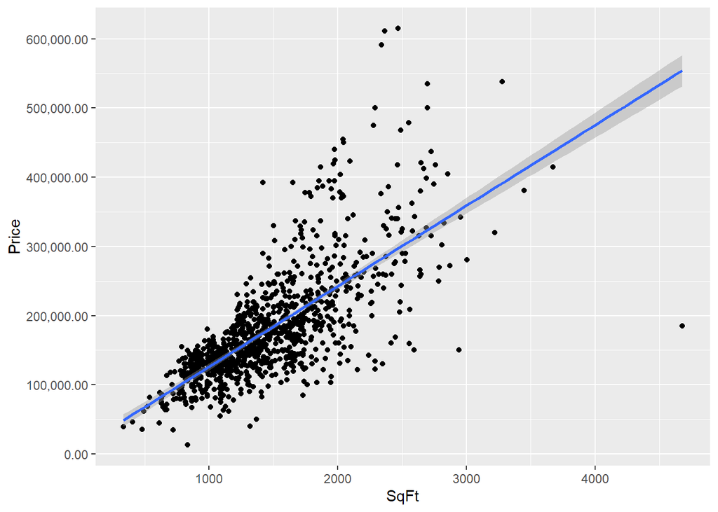

```r
ggplot(data1, aes(x=SqFt, y=price)) +
  geom_point()+
  geom_smooth(method=lm) +
  scale_y_continuous(breaks=seq(0,700000,100000), name = 'Price', labels = comma)
```

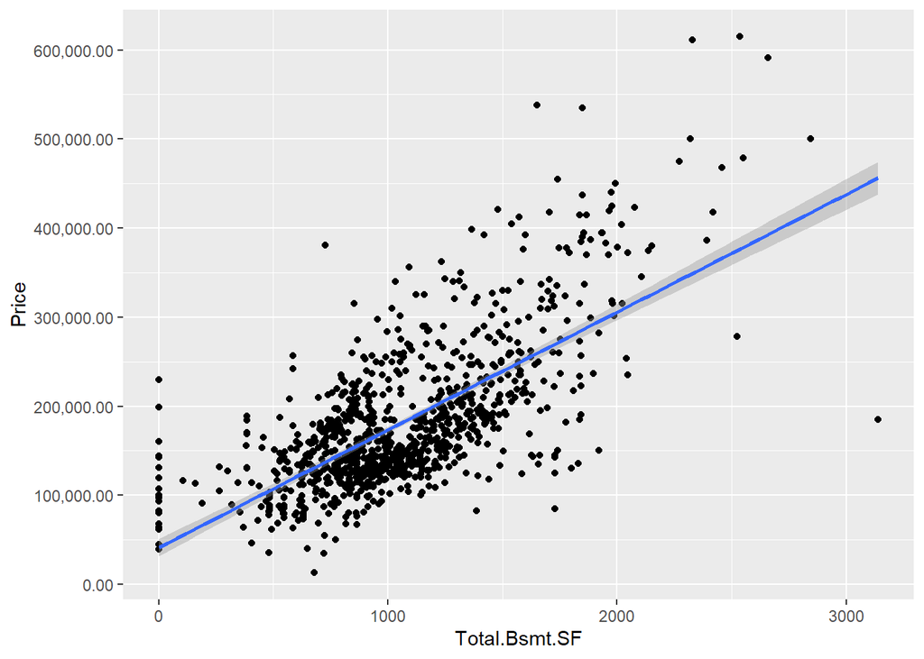

```r
ggplot(data1, aes(x=Total.Bsmt.SF, y=price)) +
  geom_point()+
  geom_smooth(method=lm) +
  scale_y_continuous(breaks=seq(0,700000,100000), name = 'Price', labels = comma)
```

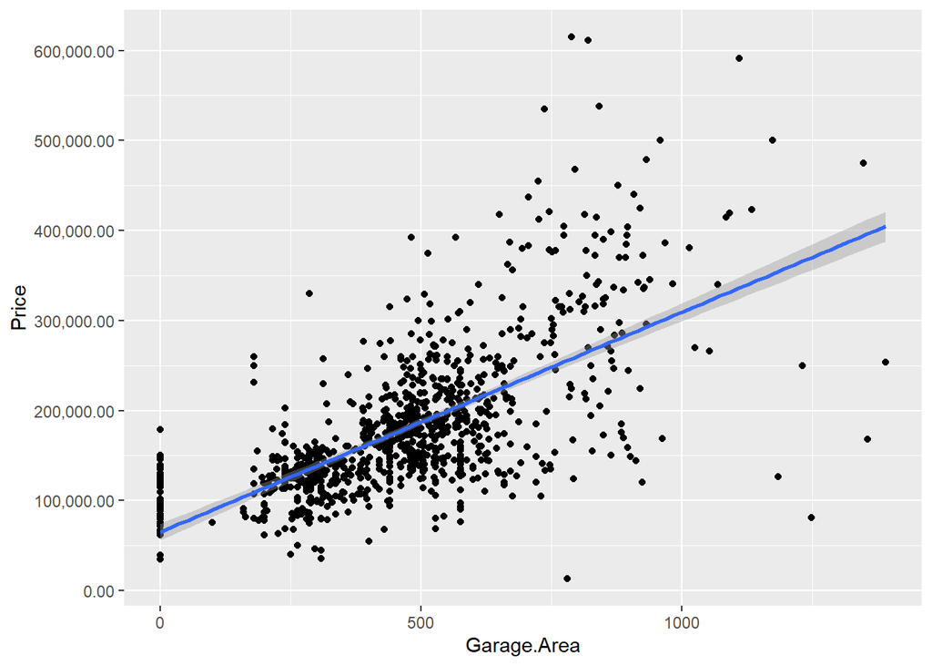

```r
ggplot(data1, aes(x=Garage.Area, y=price)) +
  geom_point()+
  geom_smooth(method=lm) +
  scale_y_continuous(breaks=seq(0,700000,100000), name = 'Price', labels = comma)
```

```r
data3 <- data1 %>%
  group_by(baths) %>%
  summarise(medianPrice = median(price), count = n())

data3$medianPrice <- currency(data3$medianPrice, digits = 0L)

kable(data3) %>%
  kable_styling(bootstrap_options = c("striped", "hover", "condensed"), position = "left", full_width = F)
```

| baths | medianPrice | count |
| --- | --- | --- |
| 0.0 | $35,311 | 1 |
| 0.5 | $262,500 | 2 |
| 1.0 | $129,000 | 337 |
| 1.5 | $148,000 | 131 |
| 2.0 | $187,300 | 288 |
| 2.5 | $216,000 | 223 |
| 3.0 | $233,938 | 8 |
| 3.5 | $333,972 | 8 |
| 5.0 | $269,500 | 2 |

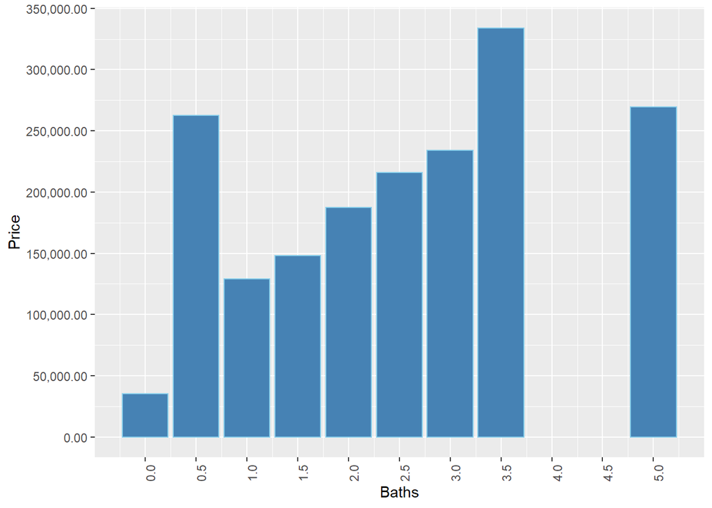

```r
ggplot(data=data3, aes(x = baths, y = medianPrice)) +
  geom_bar(stat="identity", color='skyblue', fill='steelblue') +
  theme(axis.text.x = element_text(angle = 90)) +
  scale_x_continuous(breaks=seq(0,5,0.5), name = 'Baths') +
  scale_y_continuous(breaks=seq(0,400000,50000), name = 'Price', labels = comma)
```

#### 2.1.0.1

Clearly homes always have at least 1 bathroom (only 3 records are less than 1 baths) and there’s only 2 records with 5 baths, so those should be removed in the next section to give a clearer pattern.

```r
data4 <- data1 %>%
  group_by(Bedroom.AbvGr) %>%
  summarise(medianPrice = median(price), count = n())

data4$medianPrice <- currency(data4$medianPrice, digits = 0L)

kable(data4) %>%
  kable_styling(bootstrap_options = c("striped", "hover", "condensed"), position = "left", full_width = F)
```

| Bedroom.AbvGr | medianPrice | count |
| --- | --- | --- |
| 0 | $262,500 | 2 |
| 1 | $165,500 | 45 |
| 2 | $141,500 | 275 |
| 3 | $163,000 | 533 |
| 4 | $193,500 | 122 |
| 5 | $222,250 | 14 |
| 6 | $142,953 | 9 |

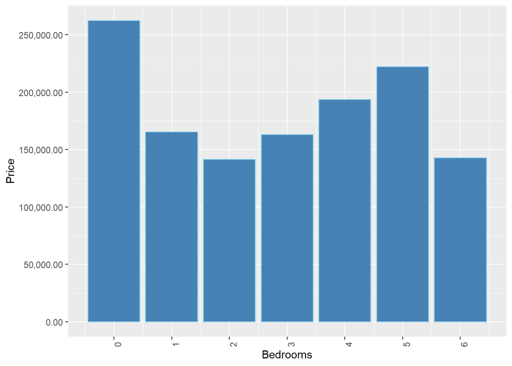

```r
ggplot(data=data4, aes(x = Bedroom.AbvGr, y = medianPrice)) +
  geom_bar(stat="identity", color='skyblue', fill='steelblue') +
  theme(axis.text.x = element_text(angle = 90)) +
  scale_x_continuous(breaks=seq(0,6,1), name = 'Bedrooms') +
  scale_y_continuous(breaks=seq(0,400000,50000), name = 'Price', labels = comma)
```

```r
data5 <- data1 %>%
  group_by(Garage.Cars) %>%
  summarise(medianPrice = median(price), count = n())

data5$medianPrice <- currency(data5$medianPrice, digits = 0L)

kable(data5) %>%
  kable_styling(bootstrap_options = c("striped", "hover", "condensed"), position = "left", full_width = F)
```

| Garage.Cars | medianPrice | count |
| --- | --- | --- |
| 0 | $98,950 | 46 |
| 1 | $127,500 | 288 |
| 2 | $178,370 | 526 |
| 3 | $315,375 | 132 |
| 4 | $245,240 | 6 |
| 5 | $126,500 | 1 |
| NA | $150,909 | 1 |

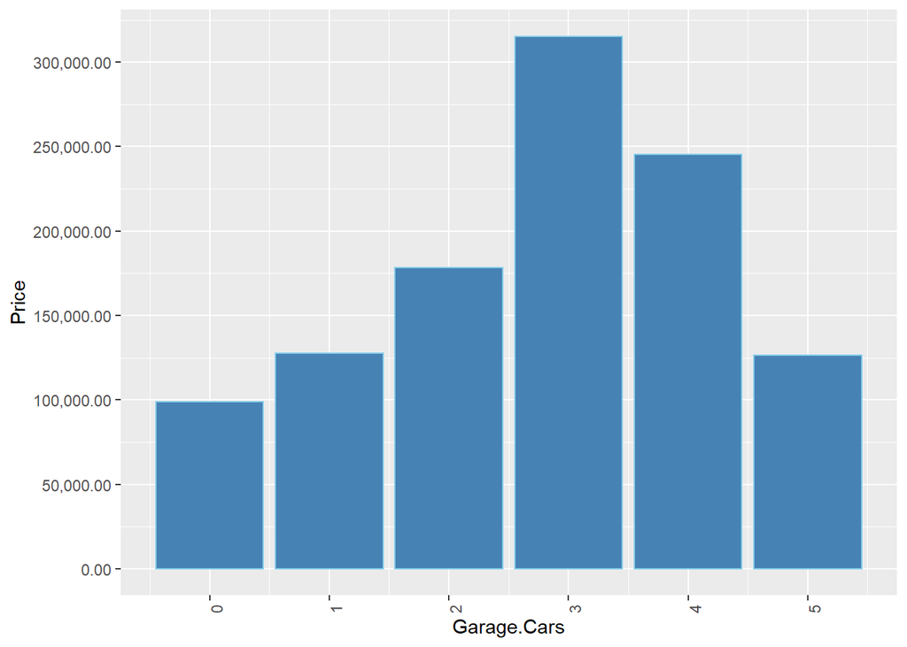

```r
ggplot(data=data5, aes(x = Garage.Cars, y = medianPrice)) +
  geom_bar(stat="identity", color='skyblue', fill='steelblue') +
  theme(axis.text.x = element_text(angle = 90)) +
  scale_x_continuous(breaks=seq(0,5,1), name = 'Garage.Cars') +
  scale_y_continuous(breaks=seq(0,400000,50000), name = 'Price', labels = comma)
```

```r
data6 <- data1 %>%
  group_by(Overall.Cond) %>%
  summarise(medianPrice = median(price), count = n())

data6$medianPrice <- currency(data6$medianPrice, digits = 0L)

kable(data6) %>%
  kable_styling(bootstrap_options = c("striped", "hover", "condensed"), position = "left", full_width = F)
```

| Overall.Cond | medianPrice | count |
| --- | --- | --- |
| 1 | $55,000 | 3 |
| 2 | $63,900 | 3 |
| 3 | $92,500 | 14 |
| 4 | $120,950 | 36 |
| 5 | $189,000 | 561 |
| 6 | $137,000 | 193 |
| 7 | $144,900 | 131 |
| 8 | $142,000 | 47 |
| 9 | $142,750 | 12 |

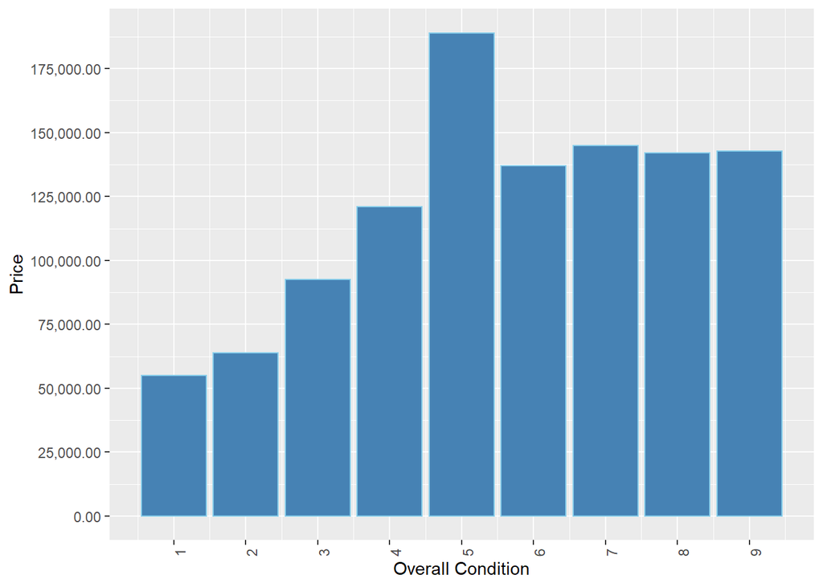

```r
ggplot(data=data6, aes(x = Overall.Cond, y = medianPrice)) +
  geom_bar(stat="identity", color='skyblue', fill='steelblue') +
  theme(axis.text.x = element_text(angle = 90)) +
  scale_x_continuous(breaks=seq(0,9,1), name = 'Overall Condition') +
  scale_y_continuous(breaks=seq(0,400000,25000), name = 'Price', labels = comma)
```

```r
data7 <- data1 %>%
  group_by(Central.Air) %>%
  summarise(medianPrice = median(price), count = n())

data7$medianPrice <- currency(data7$medianPrice, digits = 0L)

kable(data7) %>%
  kable_styling(bootstrap_options = c("striped", "hover", "condensed"), position = "left", full_width = F)
```

| Central.Air | medianPrice | count |
| --- | --- | --- |
| N | $92,900 | 55 |
| Y | $164,000 | 945 |

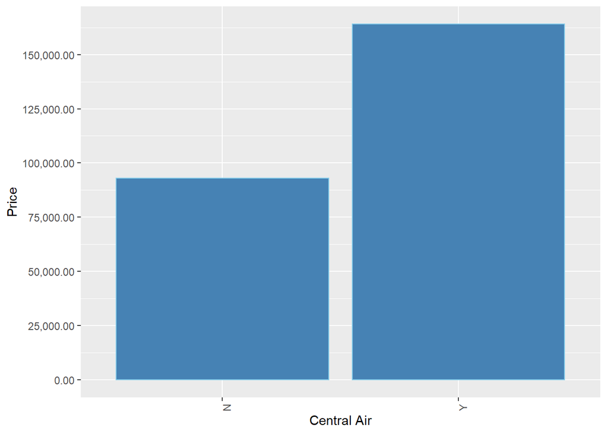

```r
ggplot(data=data7, aes(x = Central.Air, y = medianPrice)) +
  geom_bar(stat="identity", color='skyblue', fill='steelblue') +
  theme(axis.text.x = element_text(angle = 90)) +
  scale_x_discrete(name = 'Central Air') +
  scale_y_continuous(breaks=seq(0,400000,25000), name = 'Price', labels = comma)
```

## 2.2 Part 2 - Development and assessment of an initial model, following a semi-guided process of analysis

### 2.2.1 Section 2.1 An Initial Model

In building a model, it is often useful to start by creating a simple, intuitive initial model based on the results of the exploratory data analysis. (Note: The goal at this stage is **not** to identify the “best” possible model but rather to choose a reasonable and understandable starting point. Later you will expand and revise this model to create your final model.

Based on your EDA, select *at most* 10 predictor variables from “ames_train” and create a linear model for `price` (or a transformed version of price) using those variables. Provide the *R code* and the *summary output table* for your model, a *brief justification* for the variables you have chosen, and a *brief discussion* of the model results in context (focused on the variables that appear to be important predictors and how they relate to sales price).

#### 2.2.1.1

```r
# remove outliers in terms of number of baths identified in the exploratory analysis
ames_train_filtered <- data1 %>% filter(baths > 0.5) %>% filter(baths < 5)

ames_train_filtered <- stats::na.omit(ames_train_filtered)

model.full <- lm(price ~ area + SqFt + baths + Garage.Area + Total.Bsmt.SF + Central.Air,
                 data = ames_train_filtered)

summary(model.full)
```

```
##
## Call:
## lm(formula = price ~ area + SqFt + baths + Garage.Area + Total.Bsmt.SF +
##     Central.Air, data = ames_train_filtered)
##
## Residuals:
##     Min      1Q  Median      3Q     Max
## -382784  -19377     -29   16938  250865
##
## Coefficients:
##                 Estimate Std. Error t value Pr(>|t|)
## (Intercept)   -59895.570   6960.488  -8.605  < 2e-16 ***
## area             -32.194     28.014  -1.149 0.250747
## SqFt              89.246     28.166   3.169 0.001579 **
## baths          13877.613   3328.465   4.169 3.32e-05 ***
## Garage.Area       85.133      8.032  10.599  < 2e-16 ***
## Total.Bsmt.SF     68.703      3.957  17.362  < 2e-16 ***
## Central.AirY   21237.532   6335.944   3.352 0.000833 ***
## ---
## Signif. codes:  0 '***' 0.001 '**' 0.01 '*' 0.05 '.' 0.1 ' ' 1
##
## Residual standard error: 43170 on 986 degrees of freedom
## Multiple R-squared:  0.722,  Adjusted R-squared:  0.7203
## F-statistic: 426.9 on 6 and 986 DF,  p-value: < 2.2e-16
```

### 2.2.2 Section 2.2 Model Selection

Now either using `BAS` another stepwise selection procedure choose the “best” model you can, using your initial model as your starting point. Try at least two different model selection methods and compare their results. Do they both arrive at the same model or do they disagree? What do you think this means?

```r
model.AIC <- stepAIC(model.full, k = 2)
```

```
## Start:  AIC=21203.41
## price ~ area + SqFt + baths + Garage.Area + Total.Bsmt.SF + Central.Air
##
##                 Df  Sum of Sq        RSS   AIC
## - area           1 2.4614e+09 1.8401e+12 21203
## <none>                        1.8377e+12 21203
## - SqFt           1 1.8712e+10 1.8564e+12 21212
## - Central.Air    1 2.0940e+10 1.8586e+12 21213
## - baths          1 3.2399e+10 1.8700e+12 21219
## - Garage.Area    1 2.0938e+11 2.0470e+12 21309
## - Total.Bsmt.SF  1 5.6179e+11 2.3994e+12 21466
##
## Step:  AIC=21202.74
## price ~ SqFt + baths + Garage.Area + Total.Bsmt.SF + Central.Air
##
##                 Df  Sum of Sq        RSS   AIC
## <none>                        1.8401e+12 21203
## - Central.Air    1 2.0734e+10 1.8608e+12 21212
## - baths          1 3.1878e+10 1.8720e+12 21218
## - Garage.Area    1 2.1166e+11 2.0518e+12 21309
## - SqFt           1 3.0783e+11 2.1479e+12 21354
## - Total.Bsmt.SF  1 5.6062e+11 2.4007e+12 21465
```

```r
model.BIC <- stepAIC(model.full, k = log(995))
```

```
## Start:  AIC=21237.73
## price ~ area + SqFt + baths + Garage.Area + Total.Bsmt.SF + Central.Air
##
##                 Df  Sum of Sq        RSS   AIC
## - area           1 2.4614e+09 1.8401e+12 21232
## <none>                        1.8377e+12 21238
## - SqFt           1 1.8712e+10 1.8564e+12 21241
## - Central.Air    1 2.0940e+10 1.8586e+12 21242
## - baths          1 3.2399e+10 1.8700e+12 21248
## - Garage.Area    1 2.0938e+11 2.0470e+12 21338
## - Total.Bsmt.SF  1 5.6179e+11 2.3994e+12 21496
##
## Step:  AIC=21232.15
## price ~ SqFt + baths + Garage.Area + Total.Bsmt.SF + Central.Air
##
##                 Df  Sum of Sq        RSS   AIC
## <none>                        1.8401e+12 21232
## - Central.Air    1 2.0734e+10 1.8608e+12 21236
## - baths          1 3.1878e+10 1.8720e+12 21242
## - Garage.Area    1 2.1166e+11 2.0518e+12 21333
## - SqFt           1 3.0783e+11 2.1479e+12 21379
## - Total.Bsmt.SF  1 5.6062e+11 2.4007e+12 21489
```

```r
summary(model.AIC)
```

```
##
## Call:
## lm(formula = price ~ SqFt + baths + Garage.Area + Total.Bsmt.SF +
##     Central.Air, data = ames_train_filtered)
##
## Residuals:
##     Min      1Q  Median      3Q     Max
## -383161  -19266    -107   17011  250866
##
## Coefficients:
##                 Estimate Std. Error t value Pr(>|t|)
## (Intercept)   -60168.750   6957.557  -8.648  < 2e-16 ***
## SqFt              57.285      4.458  12.850  < 2e-16 ***
## baths          13758.907   3327.402   4.135 3.85e-05 ***
## Garage.Area       85.521      8.026  10.655  < 2e-16 ***
## Total.Bsmt.SF     68.619      3.957  17.341  < 2e-16 ***
## Central.AirY   21130.920   6336.294   3.335 0.000885 ***
## ---
## Signif. codes:  0 '***' 0.001 '**' 0.01 '*' 0.05 '.' 0.1 ' ' 1
##
## Residual standard error: 43180 on 987 degrees of freedom
## Multiple R-squared:  0.7217, Adjusted R-squared:  0.7203
## F-statistic: 511.8 on 5 and 987 DF,  p-value: < 2.2e-16
```

```r
summary(model.BIC)
```

```
##
## Call:
## lm(formula = price ~ SqFt + baths + Garage.Area + Total.Bsmt.SF +
##     Central.Air, data = ames_train_filtered)
##
## Residuals:
##     Min      1Q  Median      3Q     Max
## -383161  -19266    -107   17011  250866
##
## Coefficients:
##                 Estimate Std. Error t value Pr(>|t|)
## (Intercept)   -60168.750   6957.557  -8.648  < 2e-16 ***
## SqFt              57.285      4.458  12.850  < 2e-16 ***
## baths          13758.907   3327.402   4.135 3.85e-05 ***
## Garage.Area       85.521      8.026  10.655  < 2e-16 ***
## Total.Bsmt.SF     68.619      3.957  17.341  < 2e-16 ***
## Central.AirY   21130.920   6336.294   3.335 0.000885 ***
## ---
## Signif. codes:  0 '***' 0.001 '**' 0.01 '*' 0.05 '.' 0.1 ' ' 1
##
## Residual standard error: 43180 on 987 degrees of freedom
## Multiple R-squared:  0.7217, Adjusted R-squared:  0.7203
## F-statistic: 511.8 on 5 and 987 DF,  p-value: < 2.2e-16
```

### 2.2.3 Section 2.3 Initial Model Residuals

One way to assess the performance of a model is to examine the model’s residuals. In the space below, create a residual plot for your preferred model from above and use it to assess whether your model appears to fit the data well. Comment on any interesting structure in the residual plot (trend, outliers, etc.) and briefly discuss potential implications it may have for your model and inference / prediction you might produce.

#### 2.2.3.1

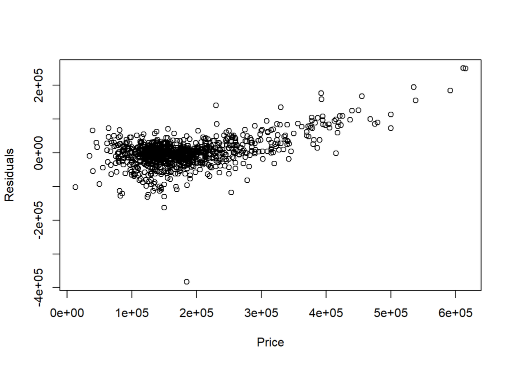

```r
pred.test.MPM <- predict(model.BIC, ames_train_filtered,
                    estimator="MPM",
                    prediction=TRUE, se.fit=TRUE)

resid.MPM = ames_train_filtered$price - pred.test.MPM$fit

ames_train_filtered1 <- ames_train_filtered %>% mutate(pred.test.MPM$fit)

colnames(ames_train_filtered1)[14] <- "fit"

ames_train_filtered1 <- ames_train_filtered1 %>% dplyr::select(price, fit)

plot(ames_train_filtered$price, resid.MPM,
     xlab="Price",
     ylab="Residuals")
```

```r
nrow(ames_train_filtered %>% filter(price < 400000))
```

```
## [1] 968
```

### 2.2.4 Section 2.4 Initial Model RMSE

You can calculate it directly based on the model output. Be specific about the units of your RMSE (depending on whether you transformed your response variable). The value you report will be more meaningful if it is in the original units (dollars).

#### 2.2.4.1

The units for the RMSE found below is dollars.

```r
pred.HPM.rmse <- sqrt(mean((pred.test.MPM$fit - ames_train_filtered$price)^2))
pred.HPM.rmse
```

```
## [1] 43047.46
```

### 2.2.5 Section 2.5 Overfitting

The process of building a model generally involves starting with an initial model (as you have done above), identifying its shortcomings, and adapting the model accordingly. This process may be repeated several times until the model fits the data reasonably well. However, the model may do well on training data but perform poorly out-of-sample (meaning, on a dataset other than the original training data) because the model is overly-tuned to specifically fit the training data. This is called “overfitting.” To determine whether overfitting is occurring on a model, compare the performance of a model on both in-sample and out-of-sample data sets. To look at performance of your initial model on out-of-sample data, you will use the data set `ames_test`.

```r
load("ames_test.Rdata")
```

Use your model from above to generate predictions for the housing prices in the test data set. Are the predictions significantly more accurate (compared to the actual sales prices) for the training data than the test data? Why or why not? Briefly explain how you determined that (what steps or processes did you use)?

Below I used the residuals plot and the RMSE to evaluate the performance of the model on the test set. As compared to the performance on the training set, the residuals plot shows that the model performs worse on the test data at higher prices. As stated previously, the model performs well at prices below $400k, which is the vast mahjority of the data (97.5%). With regard to RMSE, the model performs much better on the test data (RMSE = 35461.43) as compared to the training data (RMSE = 43047.46). This confirms that the model can perform very well on the vast majority of new houses (price < $400k).

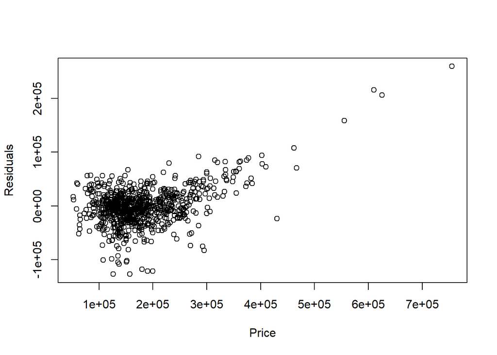

```r
ames_test_filtered <- ames_test %>%
  mutate(SqFt = X1st.Flr.SF + X2nd.Flr.SF) %>%
  mutate(baths = Full.Bath + 0.5*Half.Bath) %>%
  dplyr::select(price, Overall.Qual, Garage.Area, Total.Bsmt.SF, Garage.Cars, area, baths,
                Bedroom.AbvGr, Year.Built, SqFt, Lot.Area, Central.Air, Overall.Cond) %>%
  filter(baths > 0.5) %>% filter(baths < 5)

pred.test.MPM <- predict(model.BIC, ames_test_filtered,
                    estimator="MPM",
                    prediction=TRUE, se.fit=TRUE)

resid.MPM = ames_test_filtered$price - pred.test.MPM$fit

ames_test_filtered1 <- ames_test_filtered %>% mutate(pred.test.MPM$fit)

colnames(ames_test_filtered1)[14] <- "fit"

ames_test_filtered1 <- ames_test_filtered1 %>% dplyr::select(price, fit)

plot(ames_test_filtered$price, resid.MPM,
     xlab="Price",
     ylab="Residuals")
```

```r
pred.MPM.rmse <- sqrt(mean((pred.test.MPM$fit - ames_test_filtered$price)^2))
pred.MPM.rmse
```

```
## [1] 35461.43
```

**Note to the learner:** If in real-life practice this out-of-sample analysis shows evidence that the training data fits your model a lot better than the test data, it is probably a good idea to go back and revise the model (usually by simplifying the model) to reduce this overfitting. For simplicity, we do not ask you to do this on the assignment, however.

## 2.3 Part 3 Development of a Final Model

Now that you have developed an initial model to use as a baseline, create a final model with *at most* 20 variables to predict housing prices in Ames, IA, selecting from the full array of variables in the dataset and using any of the tools that we introduced in this specialization.

Carefully document the process that you used to come up with your final model, so that you can answer the questions below.

### 2.3.1 Section 3.1 Final Model

Provide the summary table for your model.

#### 2.3.1.1

We tried 3 additional variables that are numeric so therefore may have a relationship to price - TotRms.AbvGrd, Lot.Frontage, and a new variable for home age. Looking at the graphs below, it appears that age and TotRms.AbvGrd may have predictive power, but Lot.Frontage not so much. We’ll remove that one from the model.

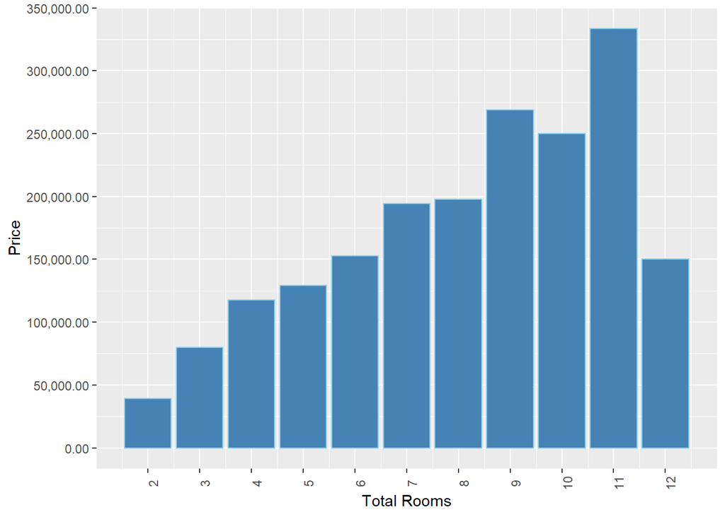

```r
data1f <- ames_train %>%
  mutate(SqFt = X1st.Flr.SF + X2nd.Flr.SF) %>%
  mutate(baths = Full.Bath + 0.5*Half.Bath) %>%
  mutate(age = 2020 - Year.Built) %>%
  dplyr::select(price, Overall.Qual, Garage.Area, Total.Bsmt.SF, Garage.Cars, area, baths,
                Bedroom.AbvGr, SqFt, Lot.Area, Overall.Cond, TotRms.AbvGrd, age, Lot.Frontage) %>%
  na.omit()

data3f <- data1f %>%
  group_by(TotRms.AbvGrd) %>%
  summarise(medianPrice = median(price), count = n())

data3f$medianPrice <- currency(data3f$medianPrice, digits = 0L)

ggplot(data=data3f, aes(x = TotRms.AbvGrd, y = medianPrice)) +
  geom_bar(stat="identity", color='skyblue', fill='steelblue') +
  theme(axis.text.x = element_text(angle = 90)) +
  scale_x_continuous(breaks=seq(0,12,1), name = 'Total Rooms') +
  scale_y_continuous(breaks=seq(0,400000,50000), name = 'Price', labels = comma)
```

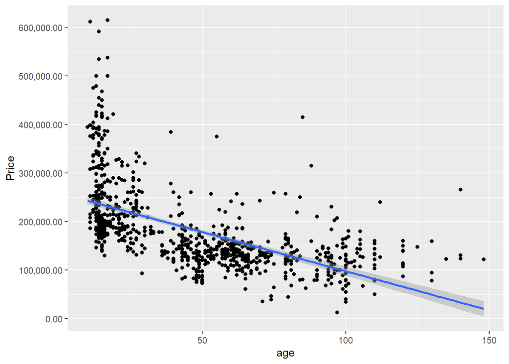

```r
ggplot(data1f, aes(x=age, y=price)) +
  geom_point()+
  geom_smooth(method=lm) +
  scale_y_continuous(breaks=seq(0,700000,100000), name = 'Price', labels = comma)
```

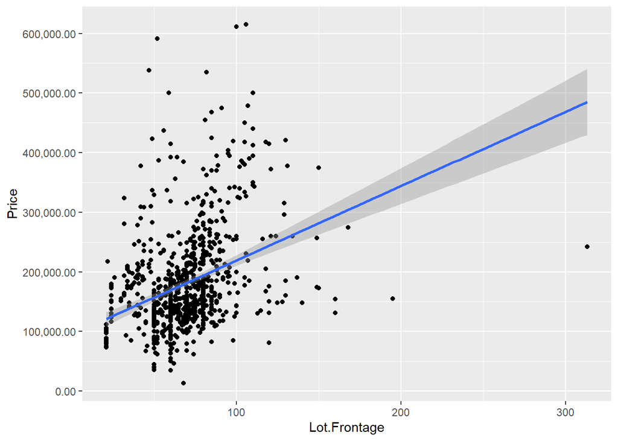

```r
ggplot(data1f, aes(x=Lot.Frontage, y=price)) +
  geom_point()+
  geom_smooth(method=lm) +
  scale_y_continuous(breaks=seq(0,700000,100000), name = 'Price', labels = comma)
```

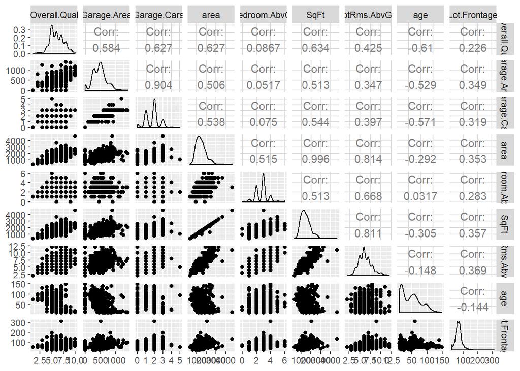

```r
ggpairs(data1f, columns = c(2,3,5,6,8,9,12,13,14))
```

```r
model.fullf <- lm(price ~ Overall.Qual + Garage.Area + Total.Bsmt.SF + Garage.Cars + area + baths +
                          Bedroom.AbvGr + SqFt, Overall.Cond + TotRms.AbvGrd + age,
                 data = data1f)

summary(model.fullf)
```

```
##
## Call:
## lm(formula = price ~ Overall.Qual + Garage.Area + Total.Bsmt.SF +
##     Garage.Cars + area + baths + Bedroom.AbvGr + SqFt, data = data1f,
##     subset = Overall.Cond + TotRms.AbvGrd + age)
##
## Residuals:
##     Min      1Q  Median      3Q     Max
## -133560  -18480    3650   20966   86546
##
## Coefficients: (1 not defined because of singularities)
##                 Estimate Std. Error t value Pr(>|t|)
## (Intercept)   -88184.906   6793.384 -12.981  < 2e-16 ***
## Overall.Qual   21326.980   1440.518  14.805  < 2e-16 ***
## Garage.Area       52.033     12.005   4.334 1.64e-05 ***
## Total.Bsmt.SF     68.239      3.639  18.752  < 2e-16 ***
## Garage.Cars    -9875.039   3497.933  -2.823  0.00487 **
## area              97.997      4.359  22.480  < 2e-16 ***
## baths           4970.388   2745.416   1.810  0.07059 .
## Bedroom.AbvGr -30553.251   1874.990 -16.295  < 2e-16 ***
## SqFt                  NA         NA      NA       NA
## ---
## Signif. codes:  0 '***' 0.001 '**' 0.01 '*' 0.05 '.' 0.1 ' ' 1
##
## Residual standard error: 32580 on 823 degrees of freedom
## Multiple R-squared:  0.9122, Adjusted R-squared:  0.9115
## F-statistic:  1222 on 7 and 823 DF,  p-value: < 2.2e-16
```

```r
model.AICf <- stepAIC(model.fullf, k = 2)
```

```
## Start:  AIC=17278.56
## price ~ Overall.Qual + Garage.Area + Total.Bsmt.SF + Garage.Cars +
##     area + baths + Bedroom.AbvGr + SqFt
##
##
## Step:  AIC=17278.56
## price ~ Overall.Qual + Garage.Area + Total.Bsmt.SF + Garage.Cars +
##     area + baths + Bedroom.AbvGr
##
##                 Df  Sum of Sq        RSS   AIC
## <none>                        8.7358e+11 17279
## - baths          1 3.4791e+09 8.7706e+11 17280
## - Garage.Cars    1 8.4598e+09 8.8204e+11 17285
## - Garage.Area    1 1.9940e+10 8.9352e+11 17295
## - Overall.Qual   1 2.3266e+11 1.1062e+12 17473
## - Bedroom.AbvGr  1 2.8185e+11 1.1554e+12 17509
## - Total.Bsmt.SF  1 3.7327e+11 1.2468e+12 17572
## - area           1 5.3640e+11 1.4100e+12 17674
```

```r
model.BICf <- stepAIC(model.fullf, k = log(995))
```

```
## Start:  AIC=17317.78
## price ~ Overall.Qual + Garage.Area + Total.Bsmt.SF + Garage.Cars +
##     area + baths + Bedroom.AbvGr + SqFt
##
##
## Step:  AIC=17317.78
## price ~ Overall.Qual + Garage.Area + Total.Bsmt.SF + Garage.Cars +
##     area + baths + Bedroom.AbvGr
##
##                 Df  Sum of Sq        RSS   AIC
## - baths          1 3.4791e+09 8.7706e+11 17314
## <none>                        8.7358e+11 17318
## - Garage.Cars    1 8.4598e+09 8.8204e+11 17319
## - Garage.Area    1 1.9940e+10 8.9352e+11 17330
## - Overall.Qual   1 2.3266e+11 1.1062e+12 17507
## - Bedroom.AbvGr  1 2.8185e+11 1.1554e+12 17543
## - Total.Bsmt.SF  1 3.7327e+11 1.2468e+12 17607
## - area           1 5.3640e+11 1.4100e+12 17709
##
## Step:  AIC=17314.18
## price ~ Overall.Qual + Garage.Area + Total.Bsmt.SF + Garage.Cars +
##     area + Bedroom.AbvGr
##
##                 Df  Sum of Sq        RSS   AIC
## - Garage.Cars    1 6.6051e+09 8.8367e+11 17314
## <none>                        8.7706e+11 17314
## - Garage.Area    1 1.8262e+10 8.9532e+11 17324
## - Overall.Qual   1 2.6675e+11 1.1438e+12 17528
## - Bedroom.AbvGr  1 2.8289e+11 1.1600e+12 17540
## - Total.Bsmt.SF  1 3.6979e+11 1.2469e+12 17600
## - area           1 5.9089e+11 1.4680e+12 17735
##
## Step:  AIC=17313.51
## price ~ Overall.Qual + Garage.Area + Total.Bsmt.SF + area + Bedroom.AbvGr
##
##                 Df  Sum of Sq        RSS   AIC
## <none>                        8.8367e+11 17314
## - Garage.Area    1 1.2846e+10 8.9651e+11 17319
## - Overall.Qual   1 2.7403e+11 1.1577e+12 17531
## - Bedroom.AbvGr  1 3.1795e+11 1.2016e+12 17562
## - Total.Bsmt.SF  1 3.8099e+11 1.2647e+12 17605
## - area           1 6.2112e+11 1.5048e+12 17749
```

```r
summary(model.AICf)
```

```
##
## Call:
## lm(formula = price ~ Overall.Qual + Garage.Area + Total.Bsmt.SF +
##     Garage.Cars + area + baths + Bedroom.AbvGr, data = data1f,
##     subset = Overall.Cond + TotRms.AbvGrd + age)
##
## Residuals:
##     Min      1Q  Median      3Q     Max
## -133560  -18480    3650   20966   86546
##
## Coefficients:
##                 Estimate Std. Error t value Pr(>|t|)
## (Intercept)   -88184.906   6793.384 -12.981  < 2e-16 ***
## Overall.Qual   21326.980   1440.518  14.805  < 2e-16 ***
## Garage.Area       52.033     12.005   4.334 1.64e-05 ***
## Total.Bsmt.SF     68.239      3.639  18.752  < 2e-16 ***
## Garage.Cars    -9875.039   3497.933  -2.823  0.00487 **
## area              97.997      4.359  22.480  < 2e-16 ***
## baths           4970.388   2745.416   1.810  0.07059 .
## Bedroom.AbvGr -30553.251   1874.990 -16.295  < 2e-16 ***
## ---
## Signif. codes:  0 '***' 0.001 '**' 0.01 '*' 0.05 '.' 0.1 ' ' 1
##
## Residual standard error: 32580 on 823 degrees of freedom
## Multiple R-squared:  0.9122, Adjusted R-squared:  0.9115
## F-statistic:  1222 on 7 and 823 DF,  p-value: < 2.2e-16
```

```r
summary(model.BICf)
```

```
##
## Call:
## lm(formula = price ~ Overall.Qual + Garage.Area + Total.Bsmt.SF +
##     area + Bedroom.AbvGr, data = data1f, subset = Overall.Cond +
##     TotRms.AbvGrd + age)
##
## Residuals:
##     Min      1Q  Median      3Q     Max
## -134264  -18518    5880   22890   84305
##
## Coefficients:
##                 Estimate Std. Error t value Pr(>|t|)
## (Intercept)   -85882.314   6640.261 -12.934  < 2e-16 ***
## Overall.Qual   20738.805   1296.580  15.995  < 2e-16 ***
## Garage.Area       26.677      7.703   3.463 0.000561 ***
## Total.Bsmt.SF     68.355      3.624  18.860  < 2e-16 ***
## area             101.374      4.210  24.081  < 2e-16 ***
## Bedroom.AbvGr -30765.056   1785.653 -17.229  < 2e-16 ***
## ---
## Signif. codes:  0 '***' 0.001 '**' 0.01 '*' 0.05 '.' 0.1 ' ' 1
##
## Residual standard error: 32730 on 825 degrees of freedom
## Multiple R-squared:  0.9112, Adjusted R-squared:  0.9106
## F-statistic:  1693 on 5 and 825 DF,  p-value: < 2.2e-16
```

```r
# Extract Predictions
predict.AICf <- predict(model.AICf, data1f,
                    estimator="MPM",
                    prediction=TRUE, se.fit=TRUE)

# Extract Residuals
resid.AICf <- data1f$price - predict.AICf$fit

# Calculate RMSE
rmse.AICf <- sqrt(mean(resid.AICf^2))
rmse.AICf
```

```
## [1] 42755.65
```

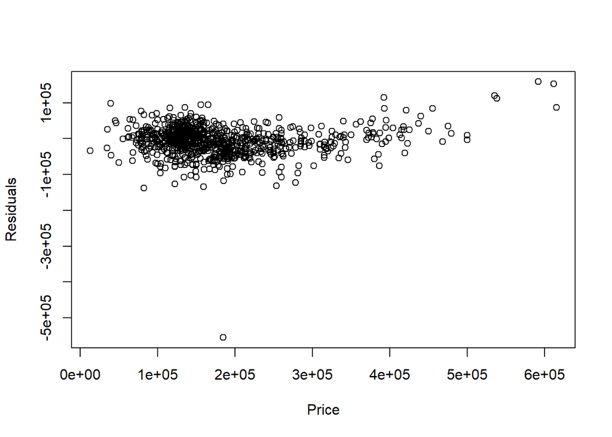

```r
data1fa <- data1f %>% mutate(predict.AICf$fit)

colnames(data1fa)[15] <- "fit"

data1fa <- data1fa %>% dplyr::select(price, fit)

plot(data1f$price, resid.AICf,
     xlab="Price",
     ylab="Residuals")
```

#### 2.3.1.2

We see that the model.AICf has the higher R^2 (0.9122), so we’ll proceed with that one. This compares very favorably to the model in the previous section, which had a R^2 of 0.7203. The model.AICf removed the variable SqFt. The model model.BICf removed SqFt, baths, and Garage.Cars.

The The RMSE of 42755.65 is comparable to that found from the smaller model in the previous section (43047.46).

The residuals plot shows that the model works very well (random scatter around 0) upto $500k, which is better than the model in the previous section. There is one extreme outlier of with a residual of -554,810.

We saw from ggpairs that area and SqFt were strongly correlated (0.996), so both are not needed. The stepAIC cosnequently removed SqFt in the final model.

### 2.3.2 Section 3.2 Transformation

Did you decide to transform any variables? Why or why not? Explain in a few sentences.

#### 2.3.2.1

No. None of the variables had a nonlinear relationship to price.

### 2.3.3 Section 3.3 Variable Interaction

Did you decide to include any variable interactions? Why or why not? Explain in a few sentences.

The SqFt variable was removed from the model. It was strongly correlated with the area variable. When 2 variables are strongly correlated, including both does not provide any more predictive power than including only one of the variables.

### 2.3.4 Section 3.4 Variable Selection

What method did you use to select the variables you included? Why did you select the method you used? Explain in a few sentences.

I used stepwise selection, which is a combination of backward and forward selection. It iteratively adds and removes variables in order to find the best performing model. I tried both AIC and BIC. AIC had a higher R^2, so we selected that model.

```r
model.AIC <- stepAIC(model.full, k = 2)
```

```
## Start:  AIC=21203.41
## price ~ area + SqFt + baths + Garage.Area + Total.Bsmt.SF + Central.Air
##
##                 Df  Sum of Sq        RSS   AIC
## - area           1 2.4614e+09 1.8401e+12 21203
## <none>                        1.8377e+12 21203
## - SqFt           1 1.8712e+10 1.8564e+12 21212
## - Central.Air    1 2.0940e+10 1.8586e+12 21213
## - baths          1 3.2399e+10 1.8700e+12 21219
## - Garage.Area    1 2.0938e+11 2.0470e+12 21309
## - Total.Bsmt.SF  1 5.6179e+11 2.3994e+12 21466
##
## Step:  AIC=21202.74
## price ~ SqFt + baths + Garage.Area + Total.Bsmt.SF + Central.Air
##
##                 Df  Sum of Sq        RSS   AIC
## <none>                        1.8401e+12 21203
## - Central.Air    1 2.0734e+10 1.8608e+12 21212
## - baths          1 3.1878e+10 1.8720e+12 21218
## - Garage.Area    1 2.1166e+11 2.0518e+12 21309
## - SqFt           1 3.0783e+11 2.1479e+12 21354
## - Total.Bsmt.SF  1 5.6062e+11 2.4007e+12 21465
```

```r
model.BIC <- stepAIC(model.full, k = log(995))
```

```
## Start:  AIC=21237.73
## price ~ area + SqFt + baths + Garage.Area + Total.Bsmt.SF + Central.Air
##
##                 Df  Sum of Sq        RSS   AIC
## - area           1 2.4614e+09 1.8401e+12 21232
## <none>                        1.8377e+12 21238
## - SqFt           1 1.8712e+10 1.8564e+12 21241
## - Central.Air    1 2.0940e+10 1.8586e+12 21242
## - baths          1 3.2399e+10 1.8700e+12 21248
## - Garage.Area    1 2.0938e+11 2.0470e+12 21338
## - Total.Bsmt.SF  1 5.6179e+11 2.3994e+12 21496
##
## Step:  AIC=21232.15
## price ~ SqFt + baths + Garage.Area + Total.Bsmt.SF + Central.Air
##
##                 Df  Sum of Sq        RSS   AIC
## <none>                        1.8401e+12 21232
## - Central.Air    1 2.0734e+10 1.8608e+12 21236
## - baths          1 3.1878e+10 1.8720e+12 21242
## - Garage.Area    1 2.1166e+11 2.0518e+12 21333
## - SqFt           1 3.0783e+11 2.1479e+12 21379
## - Total.Bsmt.SF  1 5.6062e+11 2.4007e+12 21489
```

```r
summary(model.AIC)
```

```
##
## Call:
## lm(formula = price ~ SqFt + baths + Garage.Area + Total.Bsmt.SF +
##     Central.Air, data = ames_train_filtered)
##
## Residuals:
##     Min      1Q  Median      3Q     Max
## -383161  -19266    -107   17011  250866
##
## Coefficients:
##                 Estimate Std. Error t value Pr(>|t|)
## (Intercept)   -60168.750   6957.557  -8.648  < 2e-16 ***
## SqFt              57.285      4.458  12.850  < 2e-16 ***
## baths          13758.907   3327.402   4.135 3.85e-05 ***
## Garage.Area       85.521      8.026  10.655  < 2e-16 ***
## Total.Bsmt.SF     68.619      3.957  17.341  < 2e-16 ***
## Central.AirY   21130.920   6336.294   3.335 0.000885 ***
## ---
## Signif. codes:  0 '***' 0.001 '**' 0.01 '*' 0.05 '.' 0.1 ' ' 1
##
## Residual standard error: 43180 on 987 degrees of freedom
## Multiple R-squared:  0.7217, Adjusted R-squared:  0.7203
## F-statistic: 511.8 on 5 and 987 DF,  p-value: < 2.2e-16
```

```r
summary(model.BIC)
```

```
##
## Call:
## lm(formula = price ~ SqFt + baths + Garage.Area + Total.Bsmt.SF +
##     Central.Air, data = ames_train_filtered)
##
## Residuals:
##     Min      1Q  Median      3Q     Max
## -383161  -19266    -107   17011  250866
##
## Coefficients:
##                 Estimate Std. Error t value Pr(>|t|)
## (Intercept)   -60168.750   6957.557  -8.648  < 2e-16 ***
## SqFt              57.285      4.458  12.850  < 2e-16 ***
## baths          13758.907   3327.402   4.135 3.85e-05 ***
## Garage.Area       85.521      8.026  10.655  < 2e-16 ***
## Total.Bsmt.SF     68.619      3.957  17.341  < 2e-16 ***
## Central.AirY   21130.920   6336.294   3.335 0.000885 ***
## ---
## Signif. codes:  0 '***' 0.001 '**' 0.01 '*' 0.05 '.' 0.1 ' ' 1
##
## Residual standard error: 43180 on 987 degrees of freedom
## Multiple R-squared:  0.7217, Adjusted R-squared:  0.7203
## F-statistic: 511.8 on 5 and 987 DF,  p-value: < 2.2e-16
```

### 2.3.5 Section 3.5 Model Testing

How did testing the model on out-of-sample data affect whether or how you changed your model? Explain in a few sentences.

No it did not. The spread of the residuals was roughly the same, although the one extreme outlier was absent, so the scale of the plot changed. Also, the RMSE is lower for the model with the test data.

```r
data1fa <- ames_test %>%
  mutate(SqFt = X1st.Flr.SF + X2nd.Flr.SF) %>%
  mutate(baths = Full.Bath + 0.5*Half.Bath) %>%
  mutate(age = 2020 - Year.Built) %>%
  dplyr::select(price, Overall.Qual, Garage.Area, Total.Bsmt.SF, Garage.Cars, area, baths,
                Bedroom.AbvGr, SqFt, Lot.Area, Overall.Cond, TotRms.AbvGrd, age, Lot.Frontage) %>%
  na.omit()

# Extract Predictions
predict.AICfa <- predict(model.AICf, data1fa,
                    estimator="MPM",
                    prediction=TRUE, se.fit=TRUE)

# Extract Residuals
resid.AICfa <- data1fa$price - predict.AICfa$fit

# Calculate RMSE
rmse.AICfa <- sqrt(mean(resid.AICfa^2))
rmse.AICfa
```

```
## [1] 37118.46
```

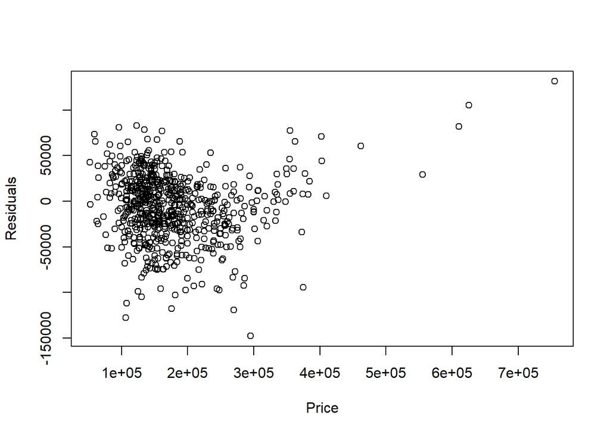

```r
data1fa <- data1fa %>% mutate(predict.AICfa$fit)

colnames(data1fa)[15] <- "fit"

data1fa1 <- data1fa %>% dplyr::select(price, fit)

plot(data1fa$price, resid.AICfa,
     xlab="Price",
     ylab="Residuals")
```

## 2.4 Part 4 Final Model Assessment

### 2.4.1 Section 4.1 Final Model Residual

For your final model, create and briefly interpret an informative plot of the residuals.

See residuals plot above. As stated previously, the spread of the residuals was roughly the same, although the one extreme outlier was absent, so the scale of the plot changed.

### 2.4.2 Section 4.2 Final Model RMSE

For your final model, calculate and briefly comment on the RMSE.

See RMSE given above. The RMSE is considerably lower for the test set, which is a good sign that the model would be useful in predicting house prices in Ames.

### 2.4.3 Section 4.3 Final Model Evaluation

What are some strengths and weaknesses of your model?

Between looking at training and test set, the model is accurate for homes with prices below /$400k. This is the vast majority of the homes, so the model is likely useful in predicting prices of new homes that come on the market.

### 2.4.4 Section 4.4 Final Model Validation

Testing your final model on a separate, validation data set is a great way to determine how your model will perform in real-life practice.

You will use the “ames_validation” dataset to do some additional assessment of your final model. Discuss your findings, be sure to mention: * What is the RMSE of your final model when applied to the validation data?  
* How does this value compare to that of the training data and/or testing data? * What percentage of the 95% predictive confidence (or credible) intervals contain the true price of the house in the validation data set?  
* From this result, does your final model properly reflect uncertainty?

```r
load("ames_validation.Rdata")
```

#### 2.4.4.1

A 95% prediction interval for price should include the true value roughly 95% of the time. If the true proportion is significantly greater than or less than 0.95, then some assumptions regarding uncertainty may not be met. the out-of-sample coverage is 90.2%, so we are not as close as we would like, for our purposes we’ll assume, given the other measures of the performance, that we’ll be ok.

```r
data1fb <- ames_validation %>%
  mutate(SqFt = X1st.Flr.SF + X2nd.Flr.SF) %>%
  mutate(baths = Full.Bath + 0.5*Half.Bath) %>%
  mutate(age = 2020 - Year.Built) %>%
  dplyr::select(price, Overall.Qual, Garage.Area, Total.Bsmt.SF, Garage.Cars, area, baths,
                Bedroom.AbvGr, SqFt, Lot.Area, Overall.Cond, TotRms.AbvGrd, age, Lot.Frontage) %>%
  na.omit()

# Extract Predictions
predict.AICfb <- predict(model.AICf, data1fb,
                    estimator="MPM",
                    prediction=TRUE, se.fit=TRUE)

# Extract Residuals
resid.AICfb <- data1fb$price - predict.AICfb$fit

# Calculate RMSE
rmse.AICfb <- sqrt(mean(resid.AICfb^2))
rmse.AICfb
```

```
## [1] 38462.4
```

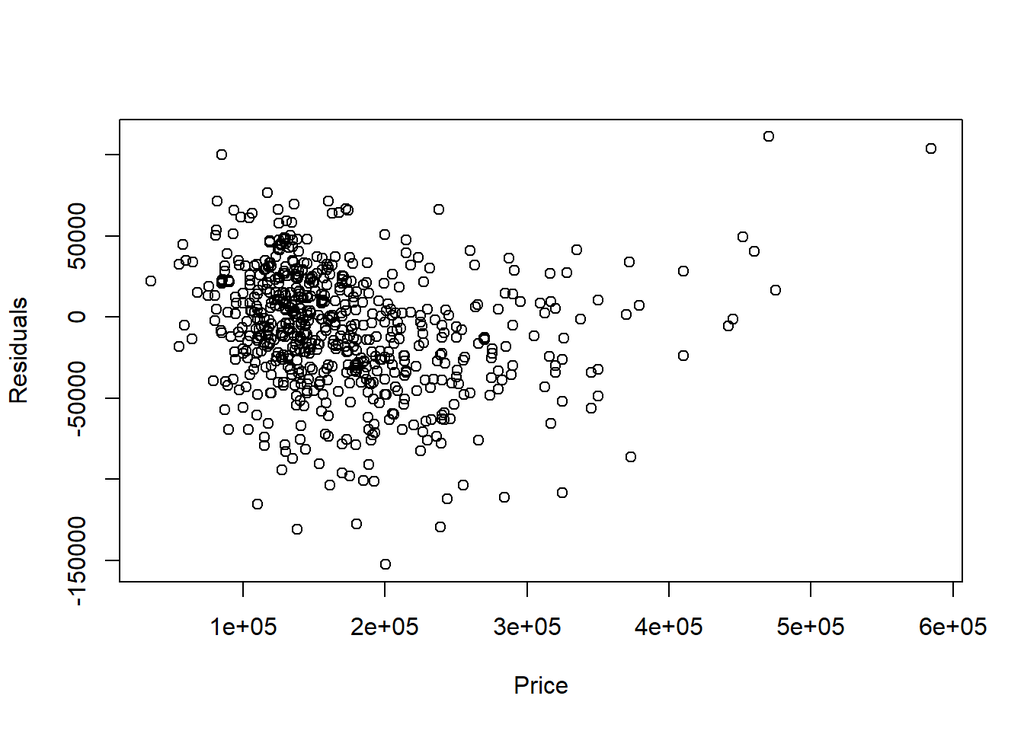

```r
data1fb <- data1fb %>% mutate(predict.AICfb$fit)

colnames(data1fb)[15] <- "fit"

data1fb1 <- data1fb %>% dplyr::select(price, fit)

plot(data1fb$price, resid.AICfb,
     xlab="Price",
     ylab="Residuals")
```

```r
# Calculate proportion of observations that fall within prediction intervals
predict.AICfb1 <- predict(model.AICf, data1fb, interval = "prediction")

coverage.prob.full <- mean(data1fb$price > predict.AICfb1[,"lwr"] &
                            data1fb$price < predict.AICfb1[,"upr"])
coverage.prob.full
```

```
## [1] 0.9015873
```

## 2.5 Part 5 Conclusion

Provide a brief summary of your results, and a brief discussion of what you have learned about the data and your model.

#### 2.5.0.1

As stated above, the model performs reasoanbly well for prices below $400k, which is the vast majority of the data. There is a lot of variation in the price and a few outliers exist that could have affected performance. As long as the model is used with common sense by someone knowledgeable about the market, which presumably our customer has people with knowledge of the market.